# Utility of contrast enhanced ultrasonography for detecting residual liver tumor early after transarterial chemoembolization: A diagnostic metanalysis

Made Vidyasti Laksita Wijaya, Kadek Adit Wiryadana

Buleleng, 2022-11-02

## Abstract

#### Background

Transarterial chemoembolization (TACE) is the recommended treatment for intermediate stage, unresectable, Hepatocellular Carcinomas (HCC). TACE is local delivery of embolization and chemotherapeutic particle that might not achieve a complete therapeutic response. Early evaluation for residual tumor warrants a chance for immediate re-treatment. Contrast-enhanced Ultrasonography (CEUS) is among the most promising modality for early evaluation.

#### Objective

This study aimed to gather evidence for diagnostic performance of CEUS in detecting residual tumor within 24-72 hours after TACE.

#### Methods

Literature search were conducted through PubMed, Europe PMC, and Google Scholar up to September 30th, 2022. Literatures were screened and evaluated for risk of bias with QUADAS-2. Pooled sensitivity, specificity, positive predictive value (PPV), negative predictive value (NPV), diagnostic odd ratio (DOR) calculated with R and Meta package. Area under the curve (AUC) from the summary of the receiver operating characteristics (sROC) curve were computed according Reitsma method to get the overall diagnostic performance conducted using R and Mada package.

#### Conclusion

CEUS has shown a reliable sensitivity and specificity for detecting residual tumor within 72 hours after TACE, albeit the current data showed a significant between study heterogeneity.

##### Keywords

Contrast-enhanced ultrasonography, Diagnostics test accuracy meta-analysis, Hepatocellular carcinoma, Transarterial chemoembolization

## Introduction

Transarterial chemoembolization (TACE) is the recommended treatment of choice for intermediate stage HCCs.<sup>1</sup> The underlying principle of TACE is inducing tumor tissue hypoxia with the selective delivery of embolization particles together with a chemotherapeutic drug. TACE is still considered a palliative method, although it might achieve a complete therapeutic response, small numbers of malignant cells can escape necrosis.<sup>2</sup> Early evaluation and detection of those residual tumor warrant a chance for immediate repeat treatment.<sup>3–6</sup> Thereby, the modality for early detection is paramount important. The most promising modality is the contrast-enhanced ultrasonography (CEUS). This study aimed to gather evidence for diagnostic performance of CEUS in detecting residual tumor within 24-72 hours after TACE treatment.

## Methods

### Literature Search

Data from literature up to September 2022 were searched from PubMed, Europe PMC and Google schoolar. The search term were combination of following: (1) hepatocelular carcinoma, liver carcinoma, liver cancer, hepatoma and HCC; (2) transarterial chemoembolization and TACE; and (3) contrast enhanced ultrasound, contrast enhanced ultrasonography and CEUS.

### Study Selection

Studies were included in the analysis if they met the following inclusion criteria: (1) all participant received TACE treatment for hepatocelular carcinoma; (2) all participant had CEUS examination within 72 hours after TACE; (3) All participant undwerwent confirmation test after 1 month with Contrast Enhanced Computed Tomography (CECT) or Magnetic Resonance Imaging (MRI) or both; (4) The study included the absolute number of true-positive, true-negative, false-positive, false-negative or the value of sensitivity, specificitty, positive predictive value and negative predictive value. The study excluded if met the following criteria: (1) the publication included a case report, reviews, or editorial; (2) the study did not report the sufficient parameter of the diagnostic performance about the index test of interest. Literature search and study selection were conducted by two authors (MVLW and KAW). Discrepancy, if any, were resolved by discussion and agreement.

### Data Collection

The screened study were evaluated and the following data were collected: (1) author, publication date and study design; (2) study quality assessed by the Quality Assessment of Diagnostic Accuracy Studies (QUADAS)<sup>7</sup>; (2) investigators (MVLW and KAW) independently performed a quality assessment of the included studies, and disagreements were resolved by discussion; (3) the data regarding true positive, false-positive, false-negative, and true-negative results gathered or calculated from each study

### Risk of Bias and Quality Assement

Risk of bias of the included study was assesed with QUADAS. Visualization for study heterogeneity, indicating for variations between studies, was presented with SROC and Cross-Hairs plots as well as calculation for $I^2$ statistics. if an $I^2$ indicate significant heterogeneity, data were pooled by random-effects model, otherwise it pooled by fixed-effects model.

### Statistical Analysis

The collected data were tabulated in spreadsheet (Google Sheet) and analyzed in R statistical language (v 4.1.2)<sup>8</sup> through Rstudio interface (RStudio Server 2022.02.3+492 for Ubuntu Bionic).<sup>9,10</sup> Diagnostic metanalysis specific calculation conducted using Mada package.<sup>11</sup> Univariate analysis of diagnostic performance conducted using metaprop function from Meta package.<sup>12</sup> The main analysis was focused on the pooled diagnostic parameter of CEUS early after TACE in detecting residual tumors. The pooled sensitivity, specificity, positive predictive value (PPV), negative predictive value (NPV), positive likelihood ratio (PLR), negative likelihood ratio (NLR) and the diagnostic odds ratio were calculated using the suitable model in respect for the between study heterogeneity. The summary of diagnostic performance were presented in SROC curve. Additional R package used include rmarkdown for reproducible data calculation and manuscript preparation,<sup>13</sup> googlesheet4 for data bridging from Google Sheets to R,<sup>14</sup> gtsummary for table generation,<sup>15</sup> PRISMA2022 for PRISMA chart generation,<sup>16</sup> and robvis for risk of bias plotting.<sup>17</sup>

## Results

### Search Results

A total of 608 studies were identified by literature search. Studies were excluded after screened for title, abstract, or the entire full text. A total of four studies were suitable for the review and thus included in the metanalysis. A PRISMA flow diagram depicting the screening and review process is presented in the figure 1.<sup>18</sup>

[interactive chart not shown]

```
## [1] "/home/wiryadana/project/after_TACE/prisma.png"
```

### Summary of the Included Studies

```
## Descriptive summary of ceus with 4 primary studies.
## Confidence level for all calculations set to 95 %
## Using a continuity correction of 0.5 if applicable
##
## Diagnostic accuracies
##       sens  2.5% 97.5%  spec  2.5% 97.5%
## [1,] 0.682 0.511 0.814 0.905 0.803 0.957
## [2,] 0.948 0.846 0.984 0.808 0.537 0.938
## [3,] 0.900 0.660 0.977 0.635 0.444 0.791
## [4,] 0.790 0.619 0.897 0.955 0.679 0.995
##
## Test for equality of sensitivities:
## X-squared = 10.9525, df = 3, p-value = 0.012
## Test for equality of specificities:
## X-squared = 10.7727, df = 3, p-value = 0.013
##
##
## Diagnostic OR and likelihood ratios
##         DOR   2.5%    97.5%  posLR  2.5%   97.5% negLR  2.5% 97.5%
## [1,] 20.455  6.517   64.198  7.190 3.140  16.466 0.352 0.212 0.583
## [2,] 76.440 11.698  499.492  4.929 1.615  15.047 0.064 0.019 0.222
## [3,] 15.632  2.418  101.038  2.463 1.444   4.201 0.158 0.034 0.739
## [4,] 79.154  4.078 1536.547 17.387 1.152 262.400 0.220 0.110 0.440
##
## Correlation of sensitivities and false positive rates:
##    rho  2.5 % 97.5 %
##  0.644 -0.832  0.991
```

```
## Call:
## madauni(x = ceus, type = "DOR", method = "DSL")
##
##    DOR  tau^2
## 27.918  0.000
```

```
## Call:
## madauni(x = ceus, type = "posLR", method = "DSL")
##
## posLR tau^2
## 4.508 0.249
```

```
## Call:
## madauni(x = ceus, type = "negLR", method = "DSL")
##
## negLR tau^2
## 0.201 0.238
```

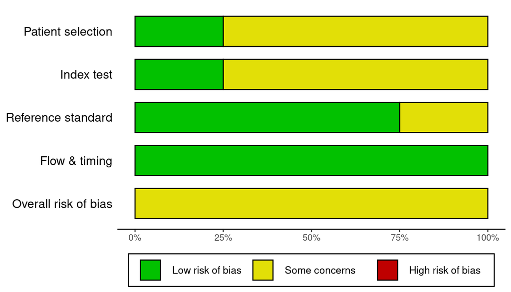

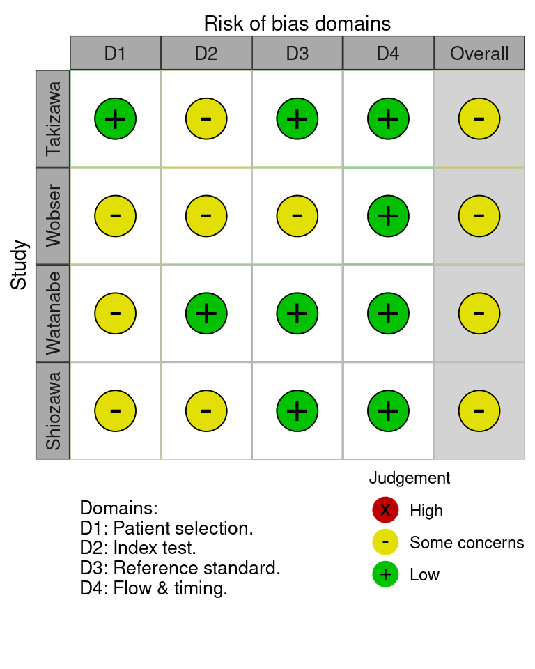

### Diagnostic Accuracy of CEUS and CECT

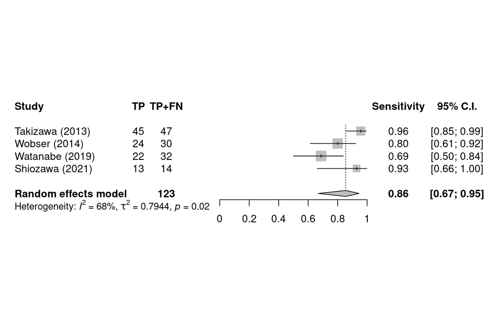

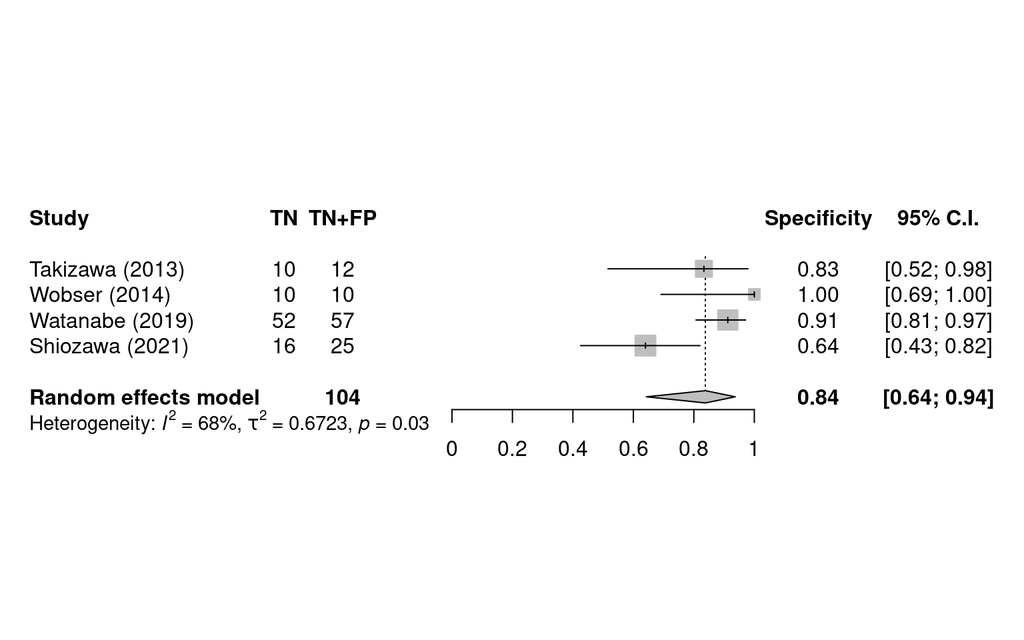

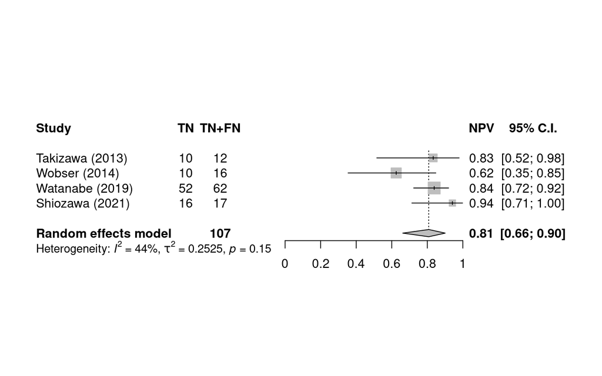

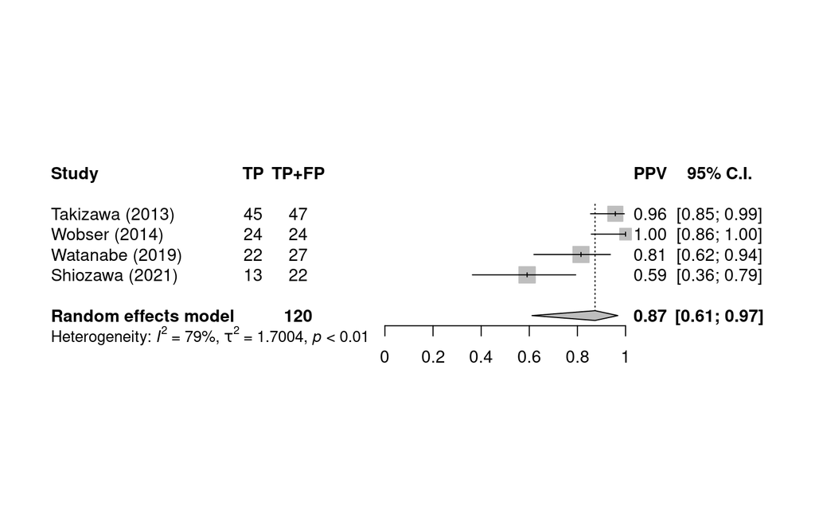

```
## Number of studies combined: k = 4
## Number of observations: o = 227
## Number of events: e = 123
##
##                         OR         95%-CI    z  p-value
## Common effect model  34.28 [14.10; 83.33] 7.80 < 0.0001
## Random effects model 34.28 [14.10; 83.33] 7.80 < 0.0001
##
## Quantifying heterogeneity:
##  tau^2 = 0 [0.0000; 8.4176]; tau = 0 [0.0000; 2.9013]
##  I^2 = 0.0% [0.0%; 84.7%]; H = 1.00 [1.00; 2.56]
##
## Test of heterogeneity:
##     Q d.f. p-value
##  2.14    3  0.5445
##
## Details on meta-analytical method:
## - Inverse variance method
## - Restricted maximum-likelihood estimator for tau^2
## - Q-Profile method for confidence interval of tau^2 and tau
## - Continuity correction of 0.5 in studies with zero cell frequencies
```

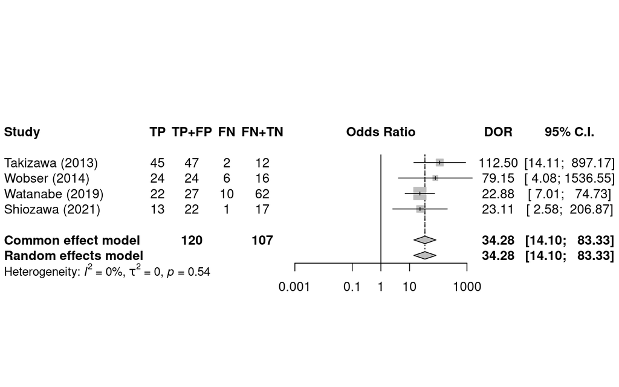

[figure not shown]

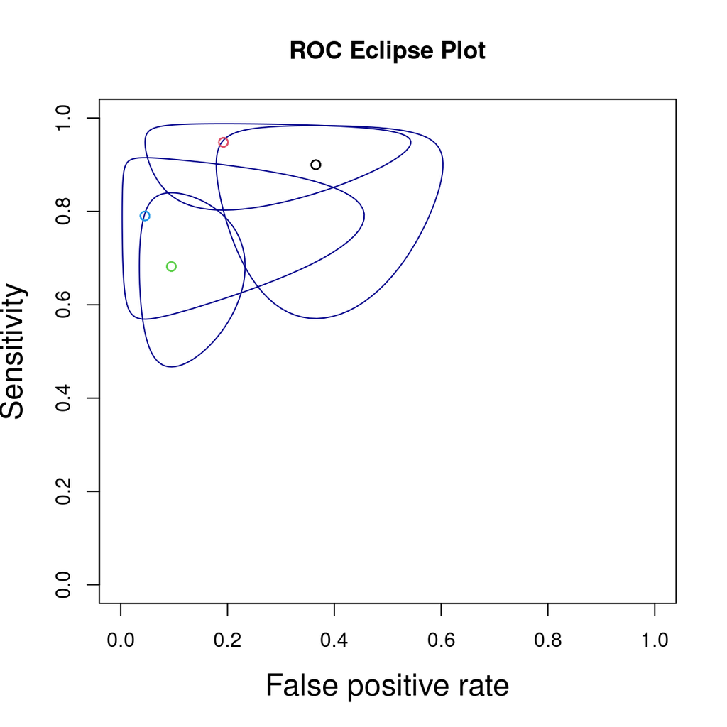

```
## Call:  reitsma.default(data = ceus)
##
## Bivariate diagnostic random-effects meta-analysis
## Estimation method: REML
##
## Fixed-effects coefficients
##                   Estimate Std. Error      z Pr(>|z|) 95%ci.lb 95%ci.ub
## tsens.(Intercept)    1.747      0.497  3.513    0.000    0.773    2.722 ***
## tfpr.(Intercept)    -1.473      0.481 -3.062    0.002   -2.416   -0.530  **
## sensitivity          0.852          -      -        -    0.684    0.938
## false pos. rate      0.186          -      -        -    0.082    0.370
## ---
## Signif. codes:  0 '***' 0.001 '**' 0.01 '*' 0.05 '.' 0.1 ' ' 1
##
## Variance components: between-studies Std. Dev and correlation matrix
##       Std. Dev tsens  tfpr
## tsens    0.835 1.000     .
## tfpr     0.757 1.000 1.000
##
## logLik    AIC    BIC
##  8.576 -7.152 -6.755
##
## AUC:  0.899
## Partial AUC (restricted to observed FPRs and normalized):  0.771
##
## I2 estimates
## Zhou and Dendukuri approach:  0 %
## Holling sample size unadjusted approaches:  28.2 - 37.3 %
## Holling sample size adjusted approaches:  1.5 - 2 %
```

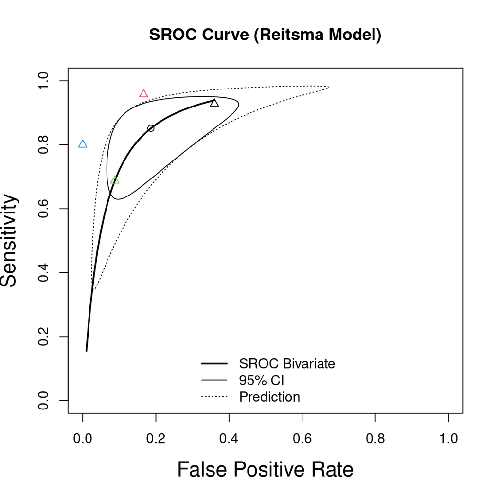

## Discussion

### Summary of the Results

Study heterogeneity: There are many causes of this heterogeneity such as chance, difference in cut-off value, difference in study design, prevalence, research environment, and the demographic factors of the sample population.<sup>19</sup>

## Conclusion

CEUS has shown a good diagnostic performace for detecting non responding tumor within 72 hours after TACE and could be utilized as a modality for early residual tumor detection.

## Disclaimer

### Funding

This study was not supported by third party funding

### Conflict of Interest

All authors declare no conflict of interest.

### Authors Contribution

Both MVLW and KAW share a proportional contribution in all phases of this study.

## References

1

Kudo M. [A new treatment option for intermediate-stage hepatocellular carcinoma with high tumor burden: Initial lenvatinib therapy with subsequent selective TACE](https://doi.org/10.1159/000502905). *Liver Cancer* 2019; **8**: 299–311.

2

Liapi E, Geschwind J-FH. [Transcatheter arterial chemoembolization for liver cancer: Is it time to distinguish conventional from drug-eluting chemoembolization?](https://doi.org/10.1007/s00270-010-0012-y) *CardioVascular and Interventional Radiology* 2010; **34**: 37–49.

3

Wobser H, Wiest R, Salzberger B, Wohlgemuth WA, Stroszczynski C, Jung E-M. [Evaluation of treatment response after chemoembolisation (TACE) in hepatocellular carcinoma using real time image fusion of contrast-enhanced ultrasound (CEUS) and computed tomography (CT) - Preliminary results](https://doi.org/10.3233/CH-141830). *Clinical Hemorheology and Microcirculation* 2014; **57**: 191–201.

4

Shiozawa K, Matsui T, Murakami T, Watanabe M, Maetani I. [Predicting Therapeutic Efficacy of Transarterial Chemoembolization with Drug-Eluting Beads for Hepatocellular Carcinoma Using Contrast-Enhanced Ultrasound](https://doi.org/10.3390/diagnostics11020291). *Diagnostics (Basel, Switzerland)* 2021; **11**: 291.

5

Takizawa K, Numata K, Morimoto M, Kondo M, Nozaki A, Moriya S *et al.* [Use of contrast-enhanced ultrasonography with a perflubutane-based contrast agent performed one day after transarterial chemoembolization for the early assessment of residual viable hepatocellular carcinoma](https://doi.org/10.1016/j.ejrad.2013.04.045). *European Journal of Radiology* 2013; **82**: 1471–1480.

6

Watanabe Y, Ogawa M, Kumagawa M, Hirayama M, Miura T, Matsumoto N *et al.* [Utility of Contrast-Enhanced Ultrasound for Early Therapeutic Evaluation of Hepatocellular Carcinoma After Transcatheter Arterial Chemoembolization](https://doi.org/10.1002/jum.15118). *Journal of Ultrasound in Medicine* 2020; **39**: 431–440.

7

Whiting P, Rutjes AW, Reitsma JB, Bossuyt PM, Kleijnen J. The development of QUADAS: A tool for the quality assessment of studies of diagnostic accuracy included in systematic reviews. *BMC Medical Research Methodology* 2003; **3**. doi:10.1186/1471-2288-3-25.

8

R Core Team. *R: A language and environment for statistical computing*. R Foundation for Statistical Computing: Vienna, Austria, 2021https://www.R-project.org/.

9

Rstudio. RStudio: Integrated Development for R. 2021.http://www.rstudio.com/.

10

Canonical. Ubuntu Server. 2021.https://wiki.ubuntu.com/FocalFossa/ReleaseNotes?_ga=2.202901329.1166669392.1642903327-1244252401.1642903327.

11

Doebler P, Sousa-Pinto B. *Mada: Meta-analysis of diagnostic accuracy*. 2022https://CRAN.R-project.org/package=mada.

12

Balduzzi S, Rücker G, Schwarzer G. How to perform a meta-analysis with R: A practical tutorial. *Evidence-Based Mental Health* 2019; : 153–160.

13

Xie Y, Allaire JJ, Grolemund G. *R markdown: The definitive guide*. Chapman; Hall/CRC: Boca Raton, Florida, 2018https://bookdown.org/yihui/rmarkdown.

14

Bryan J. *googlesheets4: Access google sheets using the sheets API V4*. 2021https://CRAN.R-project.org/package=googlesheets4.

15

Sjoberg DD, Whiting K, Curry M, Lavery JA, Larmarange J. [Reproducible summary tables with the gtsummary package](https://doi.org/10.32614/RJ-2021-053). *The R Journal* 2021; **13**: 570–580.

16

Haddaway NR, Pritchard CC, McGuinness LA. *PRISMA2020: R package and ShinyApp for producing PRISMA 2020 compliant flow diagrams (version 0.0.2)*. 2021 doi:10.5281/zenodo.5082518.

17

McGuinness LA. Robvis: An r package and web application for visualising risk-of-bias assessments. 2019.https://github.com/mcguinlu/robvis.

18

Page MJ, McKenzie JE, Bossuyt PM, Boutron I, Hoffmann TC, Mulrow CD *et al.* [The PRISMA 2020 statement: An updated guideline for reporting systematic reviews](https://doi.org/10.1136/bmj.n71). *BMJ* 2021; : n71.

19

Shim SR, Kim S-J, Lee J. [Diagnostic test accuracy: Application and practice using r software](https://doi.org/10.4178/epih.e2019007). *Epidemiology and Health* 2019; **41**: e2019007.